# Credit Card Users Churn Prediction

#### Observations

- The largest amount of attrited customers come from the Graduate education level, but this is also the largest category

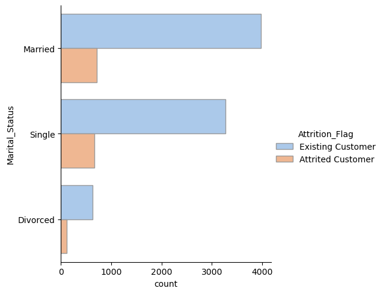

```python
# Catplot for categorical plot
sns.catplot(
    data=churn, y="Marital_Status", hue="Attrition_Flag", kind="count",
    palette="pastel", edgecolor=".6",
)
```

#### Observations

- There is not much that we can see in terms of is marital status has any bearing on attrition.

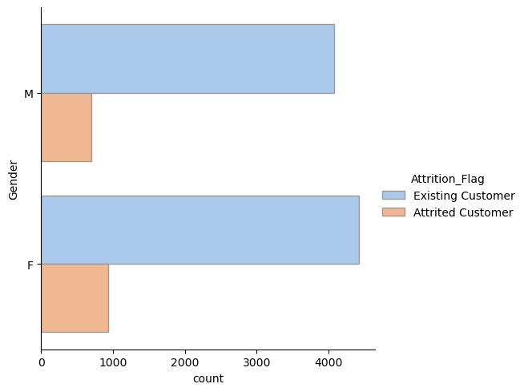

```python
# Catplot for categorical plot
sns.catplot(
    data=churn, y="Gender", hue="Attrition_Flag", kind="count",
    palette="pastel", edgecolor=".6",
)
```

#### Observations

- More females are attrition customers than males but there are more females in the data.

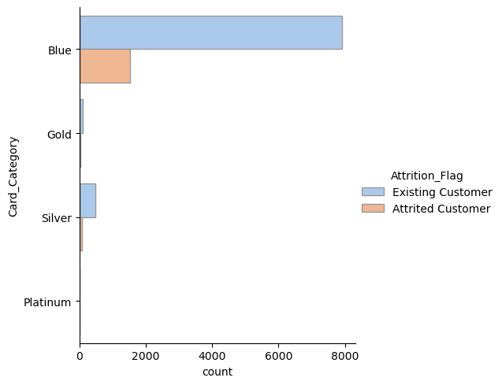

```python
# Catplot for categorical plot
sns.catplot(
    data=churn, y="Card_Category", hue="Attrition_Flag", kind="count",
    palette="pastel", edgecolor=".6",
)
```

#### Observations

- The largest amount of attrited customers come from the The Blue card, but this is also the largest category in cards

```python
# Get a distribution on the numeric data by Attrition Flag to validate plots
smallSet = churn.drop(['Months_on_book', 'Dependent_count', 'Customer_Age'], axis=1)
smallSet.groupby(['Attrition_Flag']).describe().T
```

|  | Attrition_Flag | Attrited Customer | Existing Customer |
| --- | --- | --- | --- |
| Total_Relationship_Count | count | 1627.000 | 8500.000 |
|  | mean | 3.280 | 3.915 |
|  | std | 1.578 | 1.529 |
|  | min | 1.000 | 1.000 |
|  | 25% | 2.000 | 3.000 |
|  | 50% | 3.000 | 4.000 |
|  | 75% | 5.000 | 5.000 |
|  | max | 6.000 | 6.000 |
| Months_Inactive_12_mon | count | 1627.000 | 8500.000 |
|  | mean | 2.693 | 2.274 |
|  | std | 0.900 | 1.017 |
|  | min | 0.000 | 0.000 |
|  | 25% | 2.000 | 1.000 |
|  | 50% | 3.000 | 2.000 |
|  | 75% | 3.000 | 3.000 |
|  | max | 6.000 | 6.000 |
| Contacts_Count_12_mon | count | 1627.000 | 8500.000 |
|  | mean | 2.972 | 2.356 |
|  | std | 1.091 | 1.081 |
|  | min | 0.000 | 0.000 |
|  | 25% | 2.000 | 2.000 |
|  | 50% | 3.000 | 2.000 |
|  | 75% | 4.000 | 3.000 |
|  | max | 6.000 | 5.000 |
| Credit_Limit | count | 1627.000 | 8500.000 |
|  | mean | 8136.039 | 8726.878 |
|  | std | 9095.334 | 9084.970 |
|  | min | 1438.300 | 1438.300 |
|  | 25% | 2114.000 | 2602.000 |
|  | 50% | 4178.000 | 4643.500 |

[output cut: 58 more lines]

#### Observations

- Total_Revolving_Bal, Avg_Utilization_Ratio, Total_Ct_Chng_Q4_Q1, Total_Trans_Ct, Total_Trans_Amt and Total_Revolving_Bal each have some differences between attrited and exising customers that might help to predict. This is supported by the plots as well.